# Machine_Learn_Fitness_Project.Rmd

Joe Okelly

25/09/2024

## R Markdown

Using devices such as Jawbone Up, Nike FuelBand, and Fitbit it is now possible to collect a large amount of data about personal activity relatively inexpensively. These type of devices are part of the quantified self movement – a group of enthusiasts who take measurements about themselves regularly to improve their health, to find patterns in their behavior, or because they are tech geeks. One thing that people regularly do is quantify how much of a particular activity they do, but they rarely quantify how well they do it. In this project, your goal will be to use data from accelerometers on the belt, forearm, arm, and dumbell of 6 participants. They were asked to perform barbell lifts correctly and incorrectly in 5 different ways. More information is available from the website here:

http://web.archive.org/web/20161224072740/http:/groupware.les.inf.puc-rio.br/har

## Library and download the testing and training data

```r
library(caret)
```

```r
library(rpart)
library(rpart.plot)
library(RColorBrewer)
library(rattle)
library(ggplot2)
library(randomForest)
library(knitr)

rm(list = ls())

if (!file.exists("pml-training.csv")) {
  download.file("http://d396qusza40orc.cloudfront.net/predmachlearn/pml-training.csv", destfile = "pml-training.csv")
}

if (!file.exists("pml-testing.csv")) {
  download.file("http://d396qusza40orc.cloudfront.net/predmachlearn/pml-testing.csv", destfile = "pml-testing.csv")
}

training_st <- read.csv("pml-training.csv", na.strings=c("NA","#DIV/0!",""))
testing_st <- read.csv("pml-testing.csv", na.strings=c("NA","#DIV/0!",""))
```

## Clean the data, and split it into training and testing data

```r
training_st <-training_st[,colSums(is.na(training_st)) == 0]
testing_st <-testing_st[,colSums(is.na(testing_st)) == 0]

training_st   <-training_st[,-c(1:7)]
testing_st <-testing_st[,-c(1:7)]

dim(training_st)
```

```
## [1] 19622    53
```

```r
dim(testing_st)
```

```
## [1] 20 53
```

```r
inTrain <- createDataPartition(y = training_st$classe, p=0.75, list = FALSE)
training <- training_st[inTrain, ]
testing <- training_st[-inTrain, ]

set.seed(311411)
```

## The rpart.plot function is used to create a visual representation of the decision tree

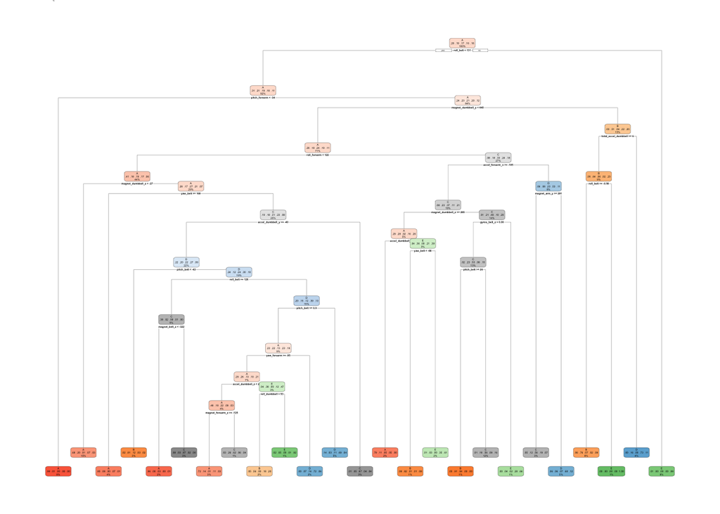

```r
fitData <- rpart(classe ~ .,training, method="class")
rpart.plot(fitData)
```

## Below model for making predictions with the decision tree model and evaluating its performance using confusion matrix

```r
predData <- predict(fitData, testing, type = "class")

#Estimate the errors of the prediction algorithm in the Decision Tree model
confusionMatrixData <-confusionMatrix(as.factor(testing$classe), predData)
confusionMatrixData
```

```
## Confusion Matrix and Statistics
##
##           Reference
## Prediction    A    B    C    D    E
##          A 1280   30   27   47   11
##          B  187  542  142   72    6
##          C   15   38  740   61    1
##          D   77   43   71  571   42
##          E   21   68  127   66  619
##
## Overall Statistics
##
##                Accuracy : 0.7651
##                  95% CI : (0.753, 0.7769)
##     No Information Rate : 0.3222
##     P-Value [Acc > NIR] : < 2.2e-16
##
##                   Kappa : 0.7018
##
##  Mcnemar's Test P-Value : < 2.2e-16
##
## Statistics by Class:
##
##                      Class: A Class: B Class: C Class: D Class: E
## Sensitivity            0.8101   0.7517   0.6685   0.6989   0.9116
## Specificity            0.9654   0.9027   0.9697   0.9430   0.9333
## Pos Pred Value         0.9176   0.5711   0.8655   0.7102   0.6870
## Neg Pred Value         0.9145   0.9547   0.9094   0.9400   0.9850
## Prevalence             0.3222   0.1470   0.2257   0.1666   0.1385
## Detection Rate         0.2610   0.1105   0.1509   0.1164   0.1262
## Detection Prevalence   0.2845   0.1935   0.1743   0.1639   0.1837
## Balanced Accuracy      0.8878   0.8272   0.8191   0.8209   0.9224
```

## fitting a Random Forest model and evaluating its performance with a confusion matrix

```r
randomForestModel <- randomForest(as.factor(classe)~., data=training)
# Summary of the model
randomForestModel
```

```
##
## Call:
##  randomForest(formula = as.factor(classe) ~ ., data = training)
##                Type of random forest: classification
##                      Number of trees: 500
## No. of variables tried at each split: 7
##
##         OOB estimate of  error rate: 0.41%
## Confusion matrix:
##      A    B    C    D    E  class.error
## A 4184    1    0    0    0 0.0002389486
## B   11 2832    5    0    0 0.0056179775
## C    0   13 2553    1    0 0.0054538372
## D    0    0   19 2391    2 0.0087064677
## E    0    0    1    7 2698 0.0029563932
```

```r
predTesting <- predict(randomForestModel, testing)
rfcfm  <- confusionMatrix(as.factor(testing$classe), predTesting)
rfcfm
```

```
## Confusion Matrix and Statistics
##
##           Reference
## Prediction    A    B    C    D    E
##          A 1394    0    0    0    1
##          B    3  943    3    0    0
##          C    0    6  849    0    0
##          D    0    0    6  796    2
##          E    0    0    0    2  899
##
## Overall Statistics
##
##                Accuracy : 0.9953
##                  95% CI : (0.993, 0.997)
##     No Information Rate : 0.2849
##     P-Value [Acc > NIR] : < 2.2e-16
##
##                   Kappa : 0.9941
##
##  Mcnemar's Test P-Value : NA
##
## Statistics by Class:
##
##                      Class: A Class: B Class: C Class: D Class: E
## Sensitivity            0.9979   0.9937   0.9895   0.9975   0.9967
## Specificity            0.9997   0.9985   0.9985   0.9981   0.9995
## Pos Pred Value         0.9993   0.9937   0.9930   0.9900   0.9978
## Neg Pred Value         0.9991   0.9985   0.9978   0.9995   0.9993
## Prevalence             0.2849   0.1935   0.1750   0.1627   0.1839
## Detection Rate         0.2843   0.1923   0.1731   0.1623   0.1833
## Detection Prevalence   0.2845   0.1935   0.1743   0.1639   0.1837
## Balanced Accuracy      0.9988   0.9961   0.9940   0.9978   0.9981
```

## Convert the Confusion Matrix table to dataframe and Plot the graph ggplot

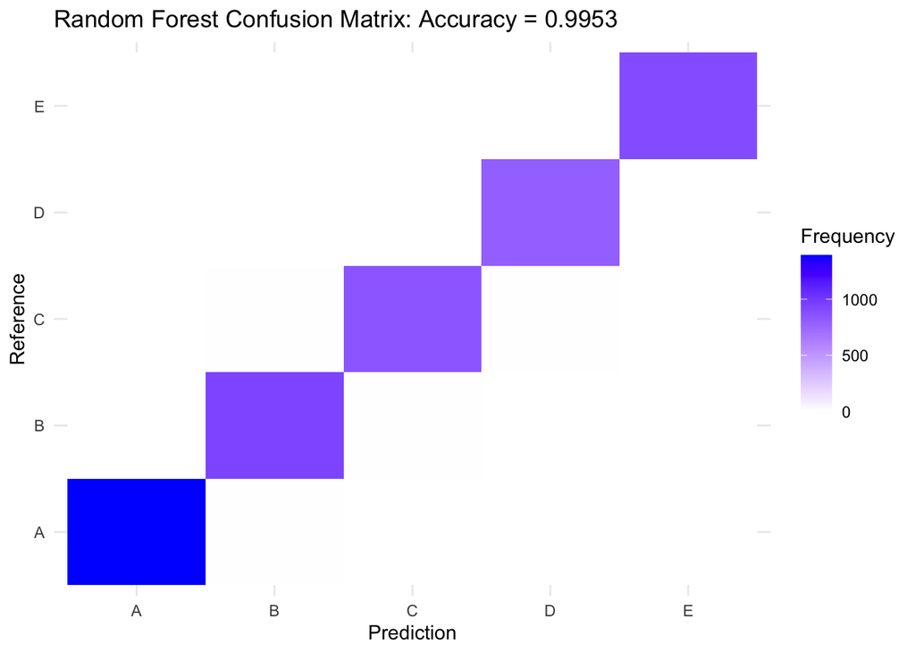

```r
cm_df <- as.data.frame(rfcfm$table)

g <- ggplot(data = cm_df, aes(x = Prediction, y = Reference, fill = Freq)) +
  geom_tile() +
  scale_fill_gradient(low = "white", high = "blue") +
  labs(title = paste("Random Forest Confusion Matrix: Accuracy =",
                     round(rfcfm$overall['Accuracy'], 4)), fill = "Frequency") +
  theme_minimal()

print(g)
```

## varImpPlot function with Random Forest model will provide a visual representation importance of each variable

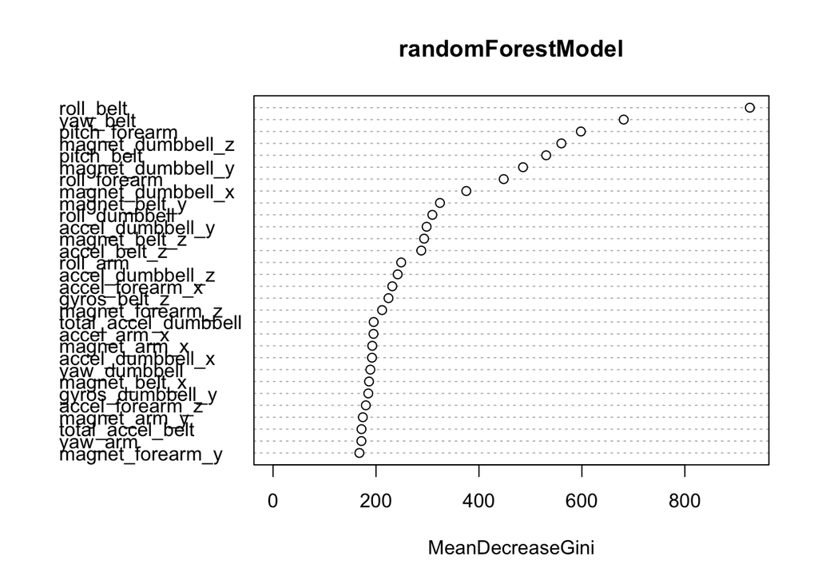

```r
varImpPlot(randomForestModel)
```

## The plot function for a Random Forest model typically generates a visual representation of the model’s error

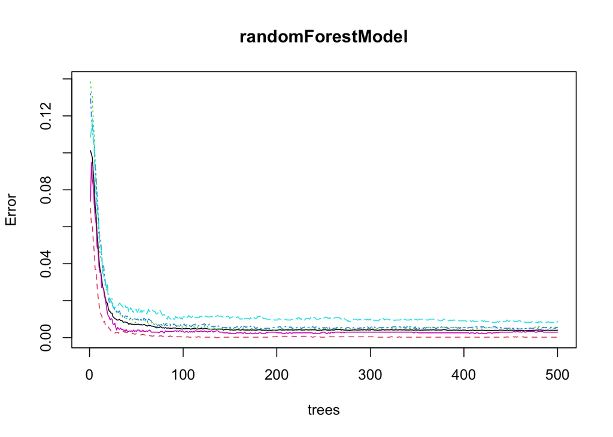

```r
plot(randomForestModel)
```

```r
rfPredict <- predict(randomForestModel, testing_st,type= "class")
rfPredict
```

```
##  1  2  3  4  5  6  7  8  9 10 11 12 13 14 15 16 17 18 19 20
##  B  A  B  A  A  E  D  B  A  A  B  C  B  A  E  E  A  B  B  B
## Levels: A B C D E
```

## Summary, Model Evaluation

The Random Forest model outperformed the decision tree, achieving higher accuracy. A confusion matrix heatmap was generated to visualize the true positives, false positives, and overall classification performance. The varImpPlot revealed the most important features driving the model’s decisions.